# Exam 3

Westley Cook

4/17/2020

## Question 1: Exploratory Data Analysis

### 1A) My hypothesis

I expect the correlation between number of migrants and the amount of remittances to be positive, because it seems intuitive that the more migrants are in a country, the more people there are who might be sending money home to other countries. Furthermore, I expect the correlation to be somewhat strong, meaning I expect the amount of remittances to rise in a pretty-close-to-linear manner with the number of migrants. I’d like to control for migrants’ income level and country/region of origin though; I imagine migrants’ money-sharing habits may differ by income, and those from poor countries/regions are probably more likely to send money home than those from rich countries/regions.

### 1B) Read and wrangle data

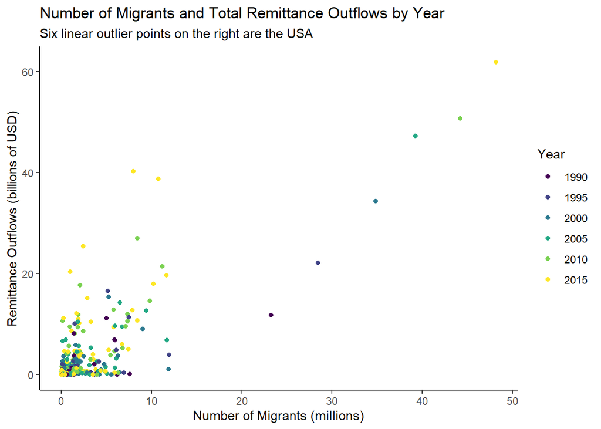

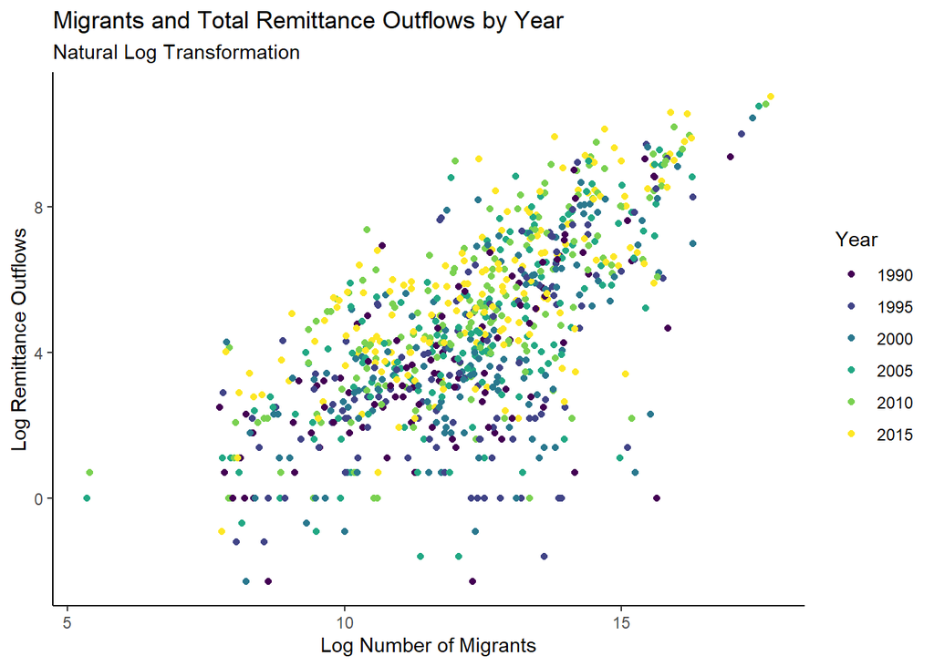

### 1C) Interpret correlation coefficients

Correlation between Migrants and Remittances by Year

From log-transformed data

| Year | Correlation |
| --- | --- |
| 1990 | 0.652 |
| 1995 | 0.572 |
| 2000 | 0.624 |
| 2005 | 0.700 |
| 2010 | 0.719 |
| 2015 | 0.725 |

Sources: UN International Migrant Stock and World Bank Remittance Data

The correlation coefficient from 2015 supports my hypothesis from 1A. There appears to be a strong positive correlation between the (logged) number of migrants and the (logged) amount of remittance outflows, meaning that an increase in one is closely associated with an increase in the other.

## Question 2: Running and Interpreting Regressions

### 2A) Run a regression

Effect of Number of Migrants on Amount of Remittances

Both IV and DV are logged

| Variable | Estimate | Lower Bound | Upper Bound |
| --- | --- | --- | --- |
| (Intercept) | -5.63 | -6.44 | -4.83 |
| log_migrants | 0.84 | 0.77 | 0.90 |

Sources: UN International Migrant Stock and World Bank Remittance Data

### 2B) Interpret the results

The estimate for log_migrants is 0.84, which tells us that on average, a 1% increase in migrants is associated with an increase of 0.84% for remittances. Unfortunately, we can’t say for certain that this is causal, since we haven’t taken all other possible variables into consideration. There is also an element of uncertainty; the lower and upper bounds of log_migrants indicate that the actual average increase in remittances associated with a 1% increase in migrants could be as low as 0.77% or as high as 0.90%.

The Bayesian interpretation of this interval is that we can be 95% confident (i.e. there’s a 95% chance) that the true average treatment effect on remittances of a 1% increase in migrants lies between 0.77% and 0.90%. The frequentist interpretation is that if we ran this same model repeatedly, it would generate an interval containing the true average treatment effect 95% of the time.

### 2C) Estimate fitted values

The formula for estimating a fitted value based on our model is

$$\hat y = b_0 + b_1 * x$$

where $\hat y$ is the predicted value of log_remittances, $b_0$ is the intercept, $b_1$ is the slope coefficient (the estimate of log_migrants from our table in 2A), and $x$ is the value of log_migrants we will use to predict log_remittances. Plugging in values from the table, when the logged number of migrants is 17.69 (as it was for the United States in 2015) we get

$$\hat y = -5.63 + 0.84 * 17.69 = 9.2296$$

which is essentially the same as R’s predict() function outputs. (The predictions differ slightly since we rounded values in the formula.)

```r
# predicting the logged remittances when log_migrants = 17.69

predict(lm(log_remittances ~ log_migrants, data = joined),
        tibble(log_migrants = 17.69))
```

```
##        1
## 9.145655
```

## Question 3: Multivariate Regression

### 3A) Run a regression

Effect of Number of Migrants on Remittances by Continent

Both IV and DV are logged

| Variable | Estimate | Lower Bound | Upper Bound |
| --- | --- | --- | --- |
| (Intercept) | -3.98 | -5.77 | -2.19 |
| log_migrants | 0.62 | 0.47 | 0.76 |
| continentAmericas | -2.45 | -4.89 | -0.02 |
| continentAsia | 1.03 | -1.62 | 3.68 |
| continentEurope | -2.57 | -5.29 | 0.14 |
| continentOceania | -0.06 | -2.59 | 2.46 |
| log_migrants:continentAmericas | 0.29 | 0.08 | 0.49 |
| log_migrants:continentAsia | 0.05 | -0.16 | 0.26 |
| log_migrants:continentEurope | 0.33 | 0.12 | 0.55 |
| log_migrants:continentOceania | 0.13 | -0.10 | 0.36 |

Sources: UN International Migrant Stock and World Bank Remittance Data

### 3B) Interpret the results

The coefficient of 0.62 for log_migrants represents the slope of the base regression line (which in this case represents the continent of Africa). It means that in Africa, on average, a 1% increase in migration is associated with a 0.62% increase in remittance outflows.

The coefficient of 0.29 for log_migrants:continentAmericas represents an offset of the slope of the base regression line, meaning that the slope of the regression line for the Americas is 0.62 + 0.29 = 0.91; so in the Americas, on average, a 1% increase in migration is associated with a 0.91% increase in remittance outflows.

The coefficient of -2.45 for continentAmericas represents an offset from the intercept, meaning that the intercept of the regression line for the Americas is -3.98 + (-2.45) = -6.43.

## Question 4: Running Many Regressions

Effect of Number of Migrants on Remittances by Year

Both IV and DV are logged

| Year | Estimated Effect | Lower Bound | Upper Bound |
| --- | --- | --- | --- |
| 1990 | 0.76 | 0.59 | 0.94 |
| 1995 | 0.76 | 0.56 | 0.96 |
| 2000 | 0.81 | 0.64 | 0.99 |
| 2005 | 0.87 | 0.73 | 1.02 |
| 2010 | 0.86 | 0.73 | 0.98 |
| 2015 | 0.80 | 0.68 | 0.92 |

Sources: UN International Migrant Stock and World Bank Remittance Data